# Content-Based_Music_Recommendation_System

# **Point Chart for various features against Popularity**

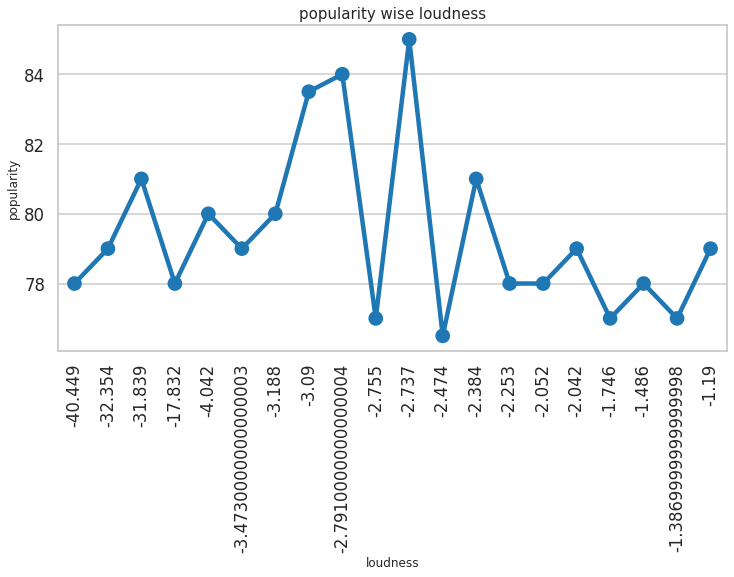

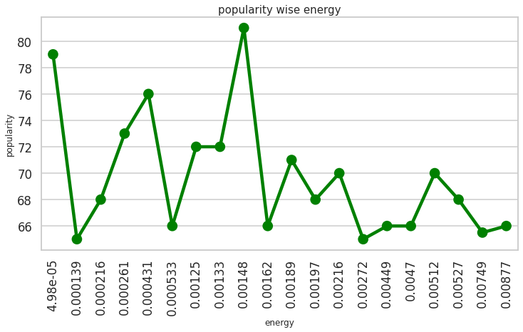

```python
ld = dataset.groupby("loudness")["popularity"].mean().sort_values(ascending=False).head(20).reset_index()
ac = dataset.groupby("acousticness")["popularity"].mean().sort_values(ascending=False).head(20).reset_index()
en = dataset.groupby("energy")["popularity"].mean().sort_values(ascending=False).head(20).reset_index()
ins = dataset.groupby("instrumentalness")["popularity"].mean().sort_values(ascending=False).head(20).reset_index()



plt.figure(figsize=(12,6))
sns.pointplot(data=ld,x="loudness", y='popularity')#,ax=axes[0])
#, color=color[4])
plt.xlabel('loudness', fontsize=12)
plt.ylabel('popularity', fontsize=12)
plt.title("popularity wise loudness", fontsize=15)
plt.xticks(rotation='vertical')
plt.show()

plt.figure(figsize=(12,6))
sns.pointplot(data=en,x="energy", y='popularity',color='g')#,ax=axes[1])
#, color=color[4])
plt.xlabel('energy', fontsize=12)
plt.ylabel('popularity', fontsize=12)
plt.title("popularity wise energy", fontsize=15)
plt.xticks(rotation='vertical')
plt.show()
```

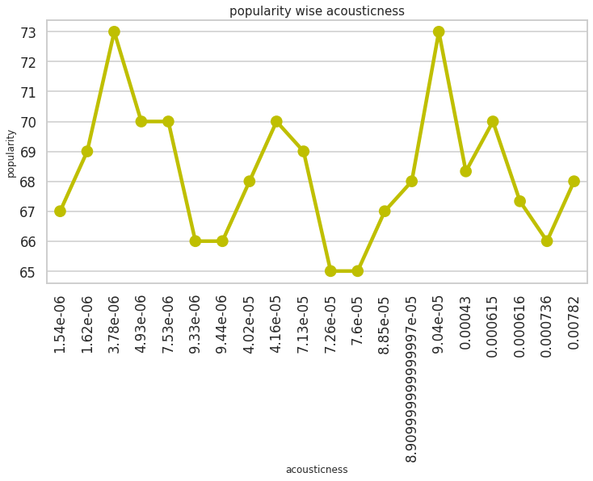

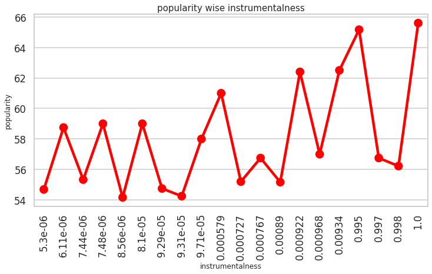

```python
plt.figure(figsize=(12,6))
sns.pointplot(data=ac,x="acousticness", y='popularity',color='y')#,ax=axes[0])
#, color=color[4])
plt.xlabel('acousticness', fontsize=12)
plt.ylabel('popularity', fontsize=12)
plt.title("popularity wise acousticness", fontsize=15)
plt.xticks(rotation='vertical')
plt.show()

plt.figure(figsize=(12,6))
sns.pointplot(data=ins,x="instrumentalness", y='popularity',color='r')#,ax=axes[0])
#, color=color[4])
plt.xlabel('instrumentalness', fontsize=12)
plt.ylabel('popularity', fontsize=12)
plt.title("popularity wise instrumentalness", fontsize=15)
plt.xticks(rotation='vertical')
plt.show()
```

# **Clustering Algorithms**

We tried 5 different clustering techniques:

- **Kmeans**
- **BIRCH**
- **MiniBatchKmeans**
- **C means**
- **Gausian Mixture**

```python
df = dataset.select_dtypes(np.number)
number_cols = list(df.columns)
```

# **Standard Scaler**

Before Clustering our data we need to scale down the features to to a given range so that the clustering algorithm dosen't favour a particular feature just because it has a greater value

```python
from sklearn.preprocessing import StandardScaler
scaler = StandardScaler()

scaled_X = scaler.fit_transform(df.values)

scaled_df = pd.DataFrame(scaled_X,
columns=df.columns)
```

### Importing metric library

```python
from sklearn import metrics
dict1 = {}
```

# **Kmeans Clustering**

K-Means clustering is an unsupervised learning algorithm, which is used when you have unlabeled data. The aim of this algorithm is to find groups in the data. K-means clustering algorithm has many uses for grouping text documents, images, videos, and much more. It works iteratively to assign each data point to one of the groups based on the Euclidean distance.

```python
from sklearn.cluster import KMeans
```

```python
kmeans = KMeans(n_clusters=8, verbose=2)
```

```python
kmeans.fit(scaled_df)
```

[output not shown]

[output cut: 328 more lines]

[output not shown]

```
KMeans(verbose=2)
```

```python
spotify_dataKmeans = dataset.copy()
spotify_dataKmeans['cluster_label'] = kmeans.predict(scaled_df)
```

```python
x = metrics.calinski_harabasz_score(pca_df, spotify_dataKmeans['cluster_label'])
print(x)
#kmeans
dict1['kmeans']=x
```

[output not shown]

```
146463.5006956746
```

```python
x = metrics.calinski_harabasz_score(scaled_df, spotify_dataKmeans['cluster_label'])
print(x)
#kmeans
dict1['kmeans']=x
```

```
20819.76377151554
```

# **BIRCH Clustering**

It is a memory-efficient, online-learning algorithm provided. It constructs a tree data structure with the cluster centroids being read off the leaf. These can be either the final cluster centroids or can be provided as input to another clustering algorithm such as AgglomerativeClustering.

```python
from sklearn.cluster import Birch
```

```python
brc = Birch(n_clusters=20)
brc.fit(pca_df)
```

```
Birch(n_clusters=20)
```

```python
spotify_dataBrich = dataset.copy()
spotify_dataBrich['cluster_label'] = brc.predict(pca_df)
```

```python
x = metrics.calinski_harabasz_score(pca_df, spotify_dataBrich['cluster_label'])
print(x) #BRICH
dict1['BRICH']=x
```

```
48577.28889830981
```

# **Mini-Batch Kmeans Clustering**

Mini Batch K-means algorithm‘s main idea is to use small random batches of data of a fixed size, so they can be stored in memory. Each iteration a new random sample from the dataset is obtained and used to update the clusters and this is repeated until convergence.

```python
from sklearn.cluster import MiniBatchKMeans
```

```python
minikmeans = MiniBatchKMeans(n_clusters=6,random_state=23,batch_size=32)

minikmeans.fit(pca_df)
```

```
MiniBatchKMeans(batch_size=32, n_clusters=6, random_state=23)
```

```python
spotify_minikmeans = dataset.copy()
spotify_minikmeans['cluster_label'] = minikmeans.predict(pca_df)
```

```python
x = metrics.calinski_harabasz_score(pca_df, spotify_minikmeans['cluster_label'])
print(x) #minibatch kmeans
dict1['minibatch kmeans']=x
```

```
136986.02646091007
```

# **Fuzzy C Mean Clustering**

Fuzzy C mean works by assigning membership to each data point corresponding to each cluster center on the basis of distance between the cluster center and the data point. More the data is near to the cluster center more is its membership towards the particular cluster center.

```python
pip install fuzzy-c-means --quiet
```

```python
from fcmeans import FCM
```

```python
fcm = FCM(n_clusters=8)
fcm.fit(pca_df)
```

```python
spotify_dataFuzzy = dataset.copy()
spotify_dataFuzzy['cluster_label'] = fcm.predict(pca_df)
```

```python
x=metrics.calinski_harabasz_score(pca_df, spotify_dataFuzzy['cluster_label'])
print(x) #fuzzy c mean
dict1['fuzzy c']=x
```

```
134405.07996641312
```

# **Gausian Mixture Model**

Gaussian Mixture Model or Mixture of Gaussian as it is sometimes called, is not so much a model as it is a probability distribution. It is a universally used model for generative unsupervised learning or clustering. It is also called Expectation-Maximization Clustering or EM Clustering and is based on the optimization strategy.

```python
from sklearn.mixture import GaussianMixture
```

```python
gm = GaussianMixture(n_components=7, random_state=23)
gm.fit(pca_df)
```

```
GaussianMixture(n_components=7, random_state=23)
```

```python
spotify_gm = dataset.copy()
spotify_gm['cluster_label'] = gm.predict(pca_df)
```

```python
x=metrics.calinski_harabasz_score(pca_df, spotify_gm['cluster_label'])
print(x)
#Gausian Mixture
dict1['Gausian Mixture']=x
```

```
141592.37758522588
```

# **Accuracy for these clustering algorithms**

We will be using the **Calinski Harabasz score** from **sklearn.metrics**

Calinski-Harabasz (CH) Index (introduced by Calinski and Harabasz in 1974) can be used to evaluate the model when ground truth labels are not known where the validation of how well the clustering has been done is made using quantities and features inherent to the dataset. The CH Index (also known as Variance ratio criterion) is a measure of how similar an object is to its own cluster (cohesion) compared to other clusters (separation).

The **Higher** the score the **Better** the Result.

```python
m = pd.DataFrame(list(dict1.items()),columns = ['cluster','score'])
```

```python
m.set_index('cluster',inplace=True)
m
```

[output not shown]

```python
import plotly.express as px
fig = px.bar(m, orientation='h')
fig.show()
```

[interactive chart not shown]

```python
from sklearn.cluster import KMeans
from sklearn.preprocessing import StandardScaler
from sklearn.pipeline import Pipeline
from sklearn.metrics.pairwise import euclidean_distances
from collections import defaultdict
```

```python
features = ['valence', 'year', 'acousticness',
            'danceability', 'duration_ms', 'energy',
            'explicit','instrumentalness', 'key',
            'liveness', 'loudness', 'mode',
            'popularity','speechiness', 'tempo']

metadata_cols = ['year', 'name',  'artists']
```

```python
song_cluster_pipeline = Pipeline([('scaler', StandardScaler()),
                                  ('kmeans', KMeans(n_clusters=8,
                                   verbose=2))],verbose=True)
X = dataset[features]
song_cluster_pipeline.fit(X)
```

```
[Pipeline] ............ (step 1 of 2) Processing scaler, total=   0.1s
Initialization complete
Iteration 0, inertia 2084723.658244635.
Iteration 1, inertia 1572210.0843939367.
```

[output not shown]

[output cut: 222 more lines]

[output not shown]

```
Pipeline(steps=[('scaler', StandardScaler()), ('kmeans', KMeans(verbose=2))],
         verbose=True)
```

```python
def input_preprocessor(song_list, dataset):

    song_vectors = []

    for song in song_list:
        try:
            song_data = dataset[(dataset['name'] == song['name']) &
                                (dataset['year'] == song['year'])].iloc[0]

        except IndexError:
            song_data = None

        if song_data is None:
            print('Warning: {} does not exist in our database'.format(song['name']))
            continue

        song_vectors.append(song_data[features].values)

    return np.mean(np.array(list(song_vectors)), axis=0)
```

```python
def tracks_groupby(list_of_dict):

    tracks_dict = {}
    for key in list_of_dict[0].keys():
        tracks_dict[key] = []

    for dictionary in list_of_dict:
        for key, value in dictionary.items():
            tracks_dict[key].append(value)

    return tracks_dict
```

```python
def Music_Recommender(song_list, dataset, n_songs=10):

    groupby_input_tracks = tracks_groupby(song_list)
    song_center = input_preprocessor(song_list, dataset)


    scaler = song_cluster_pipeline.steps[0][1]
    scaled_data = scaler.transform(dataset[features])
    scaled_song_center = scaler.transform(song_center.reshape(1, -1))


    ed_dist = euclidean_distances(scaled_song_center, scaled_data)


    index = list(np.argsort(ed_dist)[:,:n_songs][0])
    rec_output = dataset.iloc[index]


    return rec_output[metadata_cols]
```

```python
results =Music_Recommender([{'name': 'Toosie Slide', 'year': 2020},
                                          {'name': 'Outta Time (feat. Drake)', 'year': 2020},
                                          {'name': 'Chicago Freestyle (feat. Giveon)', 'year': 2020}],dataset)
results
```

|  | year | name | artists |
| --- | --- | --- | --- |
| 87767 | 2018 | I Like Me Better | ['Lauv'] |
| 152610 | 2018 | Darlin' | ['tobi lou'] |
| 106786 | 2015 | The Way (feat. Chance the Rapper) | ['Kehlani', 'Chance the Rapper'] |
| 87340 | 2014 | No Role Modelz | ['J. Cole'] |
| 135105 | 2016 | I'm The Man | ['50 Cent', 'Sonny Digital'] |
| 144303 | 2020 | Like No One Does | ['Jake Scott'] |
| 97465 | 2017 | my boy | ['Billie Eilish'] |
| 116585 | 2019 | I'll Kill You (feat. Jhené Aiko) | ['Summer Walker', 'Jhené Aiko'] |
| 24143 | 2020 | QUARANTINE CLEAN | ['Turbo', 'Gunna', 'Young Thug'] |
| 106251 | 2010 | Nikes on My Feet | ['Mac Miller'] |

```python
pip install nbconvert
```

[output not shown]

```python
!jupyter nbconvert --to html Content-Based_Music_Recommendation_System.ipynb
```